# MT F21 Key

### 3. Boxplots

In this graph we can see that the obvious happens: people who prioritize “Sleep and Social Life” get worse grades. However, what is very interesting is that the there is not a large difference regarding the median grade of people who prioritize “Social Life and Good Grades” to those who prefer “Sleep and Good Grades”. Nevertheless, the people who obtain the maximum grades overall are those who prefer to sleep over having a good social life. This makes a lot of sense because sleeping is essential to correct functioning of the brain.

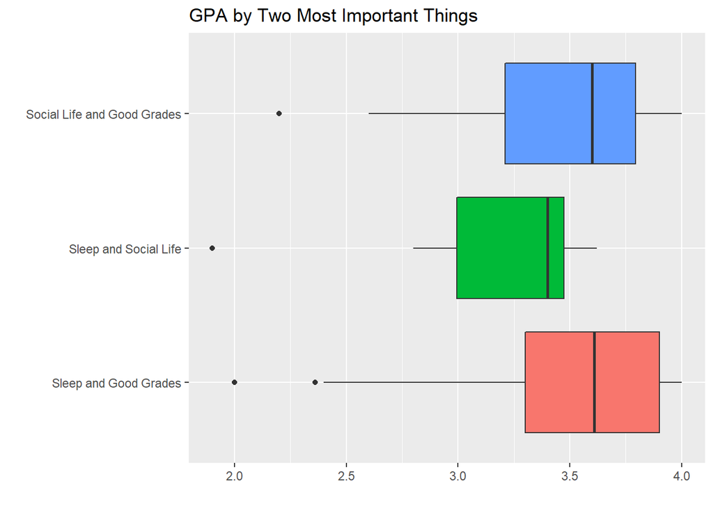

```r
# filtering of data through dpylr to remove NA in Triangle
surv3 <- surv %>% filter(!is.na(Triangle))

#  boxplot graph of GPA by Triangle
ggplot( data = surv3,
        mapping = aes( y = Triangle, x = GPA , fill = Triangle)) +
  geom_boxplot() +
  labs(title="GPA by Two Most Important Things", x = "", y = "" ) +
  guides(fill=FALSE) +
  theme_gray()
```

### 4. Stats of Earnings by Year

```r
surv %>% # data to be used
  filter(!is.na(Year))%>% # removing NAs from the Year variable
  group_by(Year) %>%  # grouping the data into groups according to Year (freshmen, sophomore, etc)
  summarise(mean_earnings = mean(Earnings), # get mean
            median_earnings = median(Earnings), # get median
            n_students = n()) # get number of students
```

```
## # A tibble: 5 x 4
##   Year        mean_earnings median_earnings n_students
##   <fct>               <dbl>           <dbl>      <int>
## 1 1st year            3018.            2750         22
## 2 2 Sophomore         5210             5000         25
## 3 3 Junior            5868.            4000         55
## 4 4 Senior            8345.            5307         85
## 5 5 Graduate         17571.           20000          7
```

### 5. Density plots of Earnings by Year

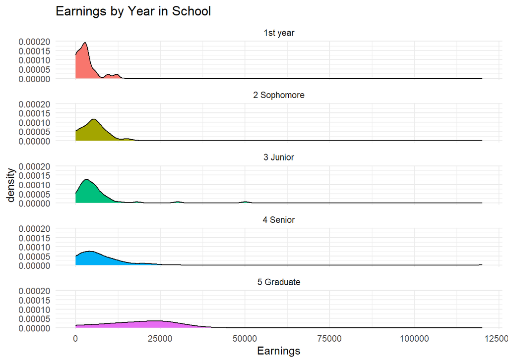

```r
# surv4 is a data frame to filter out the NAs from the Earnings
surv4 <- surv %>% filter(!is.na(Earnings))

# density graph of Year by Earnings
ggplot( data = surv4,
        mapping = aes( x = Earnings, fill=Year )) +
  geom_density() +
  facet_wrap( ~ Year,  ncol = 1) +
  theme_minimal() +
  guides(fill='none') +
  labs(title="Earnings by Year in School")
```

### 6. Top 8 and Bottom 8 GPAs

The main differences I could notice between the two groups are that the ones with highter GPA tend to eat on average more times a week breakfast and read more books for pleasure.

```r
# Creating the data frame to use in both cases
surv4 <- surv %>% # naming of the data frame and saying what data to use
  filter( !is.na(Year) ,!is.na( GPA) ,!is.na(PhoneTime) ,!is.na(Sleep) ,!is.na( Breakfast) ,!is.na(Books)) %>% # removal of NAs
  select( Year, GPA, PhoneTime, Sleep, Breakfast, Books) # selecting columns to appear

# The 8 students with highest GPA
surv4 %>% # data
  arrange(desc(GPA)) %>% # telling dplyr to arrange them in descending order according to GPA
  head(8) # selecting the first 8 entries
```

```
##          Year  GPA PhoneTime Sleep Breakfast Books
## 1    3 Junior 4.00         2   8.5         7     4
## 2    3 Junior 4.00         2   6.5         5     5
## 3    3 Junior 4.00         4   5.0         7     8
## 4 2 Sophomore 4.00         4   8.0         4     5
## 5  5 Graduate 4.00         3   8.0         7    15
## 6    4 Senior 3.98         2   8.0         3    10
## 7    4 Senior 3.98         4   7.5         7     5
## 8 2 Sophomore 3.97         4   8.0         5     2
```

```r
#  The 8 students with the lowest GPA
surv4 %>% # data
  arrange(desc(GPA)) %>% # telling dplyr to arrange them in descending order according to GPA
  tail(8) # selecting the last 8 entries
```

```
##         Year  GPA PhoneTime Sleep Breakfast Books
## 147 4 Senior 2.67       2.0   8.0         7     4
## 148 4 Senior 2.60       2.0   5.5         3     1
## 149 3 Junior 2.50       3.5   9.0         0     3
## 150 4 Senior 2.40       4.0   8.0         3     7
## 151 4 Senior 2.36       2.0   7.0         3     4
## 152 4 Senior 2.20       6.0   4.0         2     3
## 153 4 Senior 2.00       1.0   8.0         7     0
## 154 4 Senior 1.90       4.0   8.0         6     4
```

### 7. Density plots of Earnings

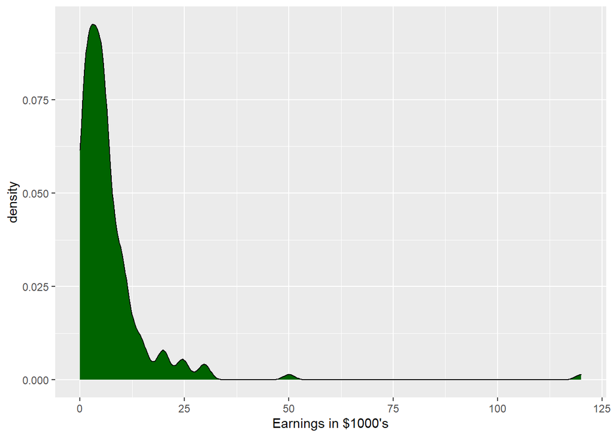

```r
# Creating data frame with the surveys' data to
surv7<- surv %>% # naming of dataframe and data to use
  filter(!is.na(Earnings))%>% # removing NAs from Earnings variable
  mutate(earnings_1000 = (Earnings / 1000)) # creating new variable where Earning's appears in 1000s of dollars

# density plot of Earnings in thousands
ggplot(data = surv7,
       mapping = aes( x= earnings_1000) ) +
  geom_density(fill="darkgreen") +
  labs(x = "Earnings in $1000's")
```

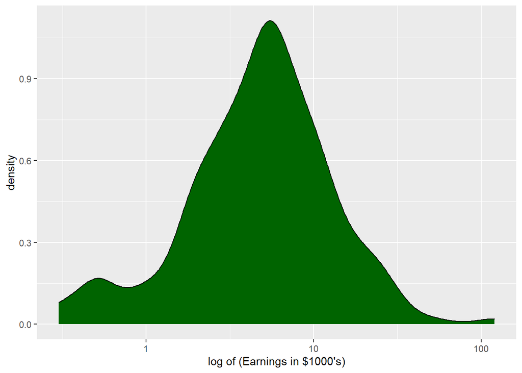

```r
# density plot of log of earnings in 1000s
ggplot(data = surv7,
       mapping = aes( x= earnings_1000) ) +
  geom_density(fill="darkgreen") +
  scale_x_log10() +
  labs(x = "log of (Earnings in $1000's)")
```

### Statement of Academic Honesty:

I confirm that I, Lucía Carrera, did not consult with any other person while doing this test, either in person, email, texting, etc. I did not look at any other person’s work, or show my work to others.